# Do rat complaints differ systematically between NYC and Chicago

Author

David zhai

# Introduction

**In the United States, many cities use centralized non-emergency reporting systems like 311, through which residents can report issues including rodent activity. These systems are often viewed as indicators of urban conditions, the complaint volumes are shaped by socioeconomic factors, trust in public institutions, and ease of reporting. Neighborhoods with similar environmental conditions may have different levels of reported complaints, depending on institutional design and resident engagement. Understanding how reporting systems produce observed outcomes is essential for interpreting administrative data and for evaluating the effectiveness of urban policy interventions. This paper examines reported rat activity in two of the largest and densest U.S. cities: New York City and Chicago. Both cities face well established rodent challenges, and maintain extensive 311 reporting infrastructures.The enforcement mechanisms, and public usage of these systems differ in meaningful ways. New York City’s 311 platform emphasizes resident initiated reporting and public transparency, whereas Chicago’s system emphasizes on service requests tied to scheduled baiting and inspection activity. These institutional differences raise an important empirical question: do observed differences in rat complaints reflect true differences in rat prevalence, or differences in how residents and governments engage with reporting systems? To address this question, the study constructs a monthly panel dataset of rat related 311 complaints at the ZIP Code Tabulation Area (ZCTA) level from 2010 through 2025. The analysis combines complaint data with weather conditions, local unemployment rates, and neighborhood characteristics drawn from the American Census. To account for systematic heterogeneity across neighborhoods, ZCTAs are grouped into socioeconomically similar clusters using principal component analysis and k-means clustering. This approach allows comparisons between New York City and Chicago within broadly comparable neighborhood types, reducing confounding from structural differences in income, population density, and racial composition.**

# Data

```r
#importing
library(DT)
library(dplyr)
library(ggplot2)
library(forecast)
library(tseries)
library(lubridate)
library(readr)
library(rnoaa)
library(zoo)
library(tidyr)
library(tidygeocoder)
library(purrr)
library(sf)
#temp
temp_data_nyc <- meteo_pull_monitors(
  monitors = "USW00094728",
  var = c("TMAX","TMIN"),
  date_min = "2010-01-01",
  date_max = "2025-10-01"
)
temp_data_chi <- meteo_pull_monitors(
  monitors = "USW00094849",
  var = c("TMAX","TMIN"),
  date_min = "2010-01-01",
  date_max = "2025-10-01"
)
#rat
rat_data_nyc <- read_csv("C:/Users/David/Downloads/Rat_Sightings_20251101.csv")
rat_data_chi <-read_csv("C:/Users/David/Downloads/311_Service_Requests_-_Rodent_Baiting_-_Historical_20251124.csv")

unemp_data_nyc <- read_csv("C:/Users/David/Downloads/NEWY636URN.csv")
unemp_data_chi <- read_csv("C:/Users/David/Downloads/CHIC917URN.csv")
names(unemp_data_nyc)[names(unemp_data_nyc) == "NEWY636URN"] <- "nyc_unemp"
names(unemp_data_chi)[names(unemp_data_chi) == "CHIC917URN"] <- "chi_unemp"
```

```r
#import cencus data for group
library(tidycensus)
library(dplyr)
library(purrr)
library(tigris)
library(sf)

options(tigris_use_cache = TRUE)



chi_counties <- c("031", "043")
nyc_counties <- c("005", "047", "061", "081", "085")



zcta_sf <- zctas(year = 2023, class = "sf")

chi_counties_sf <- counties(state = "IL", cb = TRUE, class = "sf") %>%
  filter(COUNTYFP %in% chi_counties)

nyc_counties_sf <- counties(state = "NY", cb = TRUE, class = "sf") %>%
  filter(COUNTYFP %in% nyc_counties)



chicago_zctas <- zcta_sf[st_intersects(zcta_sf, chi_counties_sf, sparse = FALSE) %>% rowSums() > 0, ]$ZCTA5CE20
nyc_zctas <- zcta_sf[st_intersects(zcta_sf, nyc_counties_sf, sparse = FALSE) %>% rowSums() > 0, ]$ZCTA5CE20



acs_vars <- c(
  pop = "B01001_001",
  income = "B19013_001",
  pov_total = "B17001_001",
  pov_below = "B17001_002",
  white = "B02001_002",
  black = "B02001_003",
  asian = "B02001_005",
  hispanic = "B03003_003"
)

 years <- 2011:2023

acs_panel <- map_df(years, function(y) {
  message("Downloading year: ", y)

  get_acs(
    geography = "zcta",
    variables = acs_vars,
    year = y,
    output = "wide"
  ) %>%
    filter(GEOID %in% c(chicago_zctas, nyc_zctas)) %>%
    mutate(
      year = y,
      city = case_when(
        GEOID %in% chicago_zctas ~ "Chicago",
        GEOID %in% nyc_zctas ~ "New York"
      ),
      poverty_rate = 100 * pov_belowE / pov_totalE
    )
})
acs_panel_clean <- na.omit(acs_panel)

chicago_geoids <- unique(acs_panel_clean$GEOID[acs_panel_clean$city == "Chicago"])
nyc_geoids <- unique(acs_panel_clean$GEOID[acs_panel_clean$city == "New York"])
zcta_file <- st_read("C:/Users/David/Downloads/tl_2023_us_zcta520/tl_2023_us_zcta520.shp")
chicago_id <- intersect(
  chicago_geoids,
  zcta_file$ZCTA5CE20
)

length(chicago_id)
```

```
[1] 228
```

```r
head(chicago_id)
```

```
[1] "46394" "60803" "60187" "60164" "60173" "60162"
```

```r
zcta_chicago <- zcta_file[zcta_file$ZCTA5CE20 %in% chicago_id, ]

setdiff(chicago_geoids, zcta_file$ZCTA5CE20)
```

```
character(0)
```

```r
nyc_id <- intersect(
  nyc_geoids,
  zcta_file$ZCTA5CE20
)
length(nyc_id)
```

```
[1] 207
```

```r
head(nyc_id)
```

```
[1] "10305" "10314" "10451" "10463" "10475" "10453"
```

```r
zcta_nyc <- zcta_file[zcta_file$ZCTA5CE20 %in% nyc_id, ]

setdiff(nyc_geoids, zcta_file$ZCTA5CE20)
```

```
character(0)
```

```r
#aggregate by zip and monthly
rat_data_nyc <- rat_data_nyc|>
 select(
  -`Unique Key`,
  -`Closed Date`,
  -Agency,
  -`Agency Name`,
  -`Complaint Type`,
  -Descriptor,
  -`Location Type`,
  -`Incident Address`,
  -`Street Name`,
  -`Cross Street 1`,
  -`Cross Street 2`,
  -`Intersection Street 1`,
  -`Intersection Street 2`,
  -`Address Type`,
  -City,
  -Landmark,
  -`Facility Type`,
  -Status,
  -`Due Date`,
  -`Resolution Action Updated Date`,
  -`Community Board`,
  -Borough,
  -`X Coordinate (State Plane)`,
  -`Y Coordinate (State Plane)`,
  -`Park Facility Name`,
  -`Park Borough`,
  -`Vehicle Type`,
  -`Taxi Company Borough`,
  -`Taxi Pick Up Location`,
  -`Bridge Highway Name`,
  -`Bridge Highway Direction`,
  -`Road Ramp`,
  -`Bridge Highway Segment`,
)
rat_data_nyc$Date <- as.Date(
  rat_data_nyc$`Created Date`,
  format = "%Y %b %d %I:%M:%S %p"
)
rat_data_nyc <- rat_data_nyc|>
  select(
    -`Created Date`
  )
rat_data_nyc$Month <- format(rat_data_nyc$Date, "%Y-%m")
```

```r
library(sf)

rat_data_nyc <- rat_data_nyc |>
  drop_na()

rats_sf_nyc <- st_as_sf(
  rat_data_nyc,
  coords = c("Longitude", "Latitude"),
  crs = 4326,   # WGS84 (standard for lat/lon)
  remove = FALSE
)

rats_sf_nyc <- st_transform(rats_sf_nyc, st_crs(zcta_nyc))

rat_data_nyc <- st_join(
  rats_sf_nyc,
  zcta_nyc[, "ZCTA5CE20"],  # only keep the ZCTA ID column
  join = st_within
)
colnames(rat_data_nyc)[colnames(rat_data_nyc) == "ZCTA5CE20"] <- "ZCTA"

rat_data_nyc <- rat_data_nyc |>
  drop_na()
rat_data_nyc$Month <- format(rat_data_nyc$Date, "%Y-%m")

rat_data_nyc <- rat_data_nyc |>
  group_by(Month, ZCTA) |>
  summarise(rat_count = n()) |>
  arrange(Month)

any(is.na(rat_data_nyc))
```

```
[1] FALSE
```

```r
#aggregate nyc temp
temp_data_nyc$date <- as.Date(temp_data_nyc$date)
temp_data_nyc <- temp_data_nyc |>
  mutate(
    tmax_c = tmax / 10,
    tmin_c = tmin / 10,
    tmax_f = tmax_c * 9/5 + 32,
    tmin_f = tmin_c * 9/5 + 32
  )
temp_data_nyc$date <- as.Date(
  temp_data_nyc$date,
  format = "%Y %b %d %I:%M:%S %p"
)
temp_data_nyc$Month <- format(temp_data_nyc$date, "%Y-%m")

temp_data_nyc <- temp_data_nyc |>
  group_by(Month) |>
  summarise(
    avg_tmax = mean(tmax_f, na.rm = TRUE),
    avg_tmin = mean(tmin_f, na.rm = TRUE),
    .groups = "drop"
  )

any(is.na(temp_data_nyc))
```

```
[1] FALSE
```

```r
unemp_data_nyc$observation_date <- as.Date(unemp_data_nyc$observation_date)

unemp_data_nyc$observation_date <- as.Date(
  unemp_data_nyc$observation_date,
  format = "%Y %b %d %I:%M:%S %p"
)
unemp_data_nyc$Month <- format(unemp_data_nyc$observation_date, "%Y-%m")

unemp_data_nyc <- unemp_data_nyc |>
  group_by(Month) |>
  summarise(
    average_unemp=mean(nyc_unemp, na.rm = TRUE),
    .groups = "drop"
  )

unemp_data_nyc <- unemp_data_nyc |>
  filter(Month > 100)
unemp_data_nyc <- unemp_data_nyc %>%
  filter(Month >= "2010-01" & Month <= "2025-10")
any(is.na(unemp_data_nyc))
```

```
[1] FALSE
```

```r
#Joinin all NYC data
NYC_data <- rat_data_nyc|>
  left_join(temp_data_nyc, by = "Month") |>
  left_join(unemp_data_nyc, by = "Month")
any(is.na(NYC_data))
```

```
[1] TRUE
```

```r
#creating variables (Cityvar)
NYC_data$City <- 1
```

```r
#creating month dummy variables
NYC_data$MonthDate <- as.Date(paste0(NYC_data$Month, "-01"))

NYC_data$MonthNum <- as.numeric(format(NYC_data$MonthDate, "%m"))

NYC_data$MonthFactor <- factor(NYC_data$MonthNum, levels = 1:12, labels = month.abb)

month_dummies <- model.matrix(~ MonthFactor - 1, data = NYC_data)

NYC_data <- cbind(NYC_data, month_dummies)

NYC_data <- NYC_data %>%
  filter( Month <= "2025-08")


any(is.na(NYC_data))
```

```
[1] FALSE
```

```r
NYC_data$ZCTA <- as.character(NYC_data$ZCTA)
```

```r
rat_data_chi <- rat_data_chi %>%
    filter(!is.na(`Creation Date`))
rat_data_chi <- rat_data_chi |>
  select(
    -Status,
    -`Completion Date`,
    -`Service Request Number`,
    -`Type of Service Request`,
    -`Number of Premises Baited`,
    -`Number of Premises with Garbage`,
    -`Number of Premises with Rats`,
    -`Current Activity`,
    -`Most Recent Action`,
    -`Street Address`,
    -`X Coordinate`,
    -`Y Coordinate`,
    -Ward,
    -`Police District`,
    -`Community Area`,
  )

rat_data_chi$Date <- as.Date(
  rat_data_chi$`Creation Date`,
  format = "%m/%d/%Y"
)
rat_data_chi <- rat_data_chi|>
 select(
    -`Creation Date`
 )

rat_data_chi$Month <- format(rat_data_chi$Date, "%Y-%m")
```

```r
library(sf)

rat_data_chi <- rat_data_chi |>
  drop_na()

chi_sf_nyc <- st_as_sf(
  rat_data_chi,
  coords = c("Longitude", "Latitude"),
  crs = 4326,   # WGS84 (standard for lat/lon)
  remove = FALSE
)

chi_sf_nyc <- st_transform(chi_sf_nyc, st_crs(zcta_chicago))

rat_data_chi <- st_join(
  chi_sf_nyc,
  zcta_chicago[, "ZCTA5CE20"],  # only keep the ZCTA ID column
  join = st_within
)

colnames(rat_data_chi)[colnames(rat_data_chi) == "ZCTA5CE20"] <- "ZCTA"


rat_data_chi <- rat_data_chi |>
  drop_na()

rat_data_chi <- rat_data_chi |>
  group_by(Month, ZCTA) |>
  summarise(rat_count = n()) |>
  arrange(Month)

any(is.na(rat_data_chi))
```

```
[1] FALSE
```

```r
#fixing chi temp
temp_data_chi$date <- as.Date(temp_data_chi$date)
temp_data_chi <- temp_data_chi |>
  mutate(
    tmax_c = tmax / 10,
    tmin_c = tmin / 10,
    tmax_f = tmax_c * 9/5 + 32,
    tmin_f = tmin_c * 9/5 + 32
  )
temp_data_chi$date <- as.Date(
  temp_data_chi$date,
  format = "%Y %b %d %I:%M:%S %p"
)
temp_data_chi$Month <- format(temp_data_chi$date, "%Y-%m")

temp_data_chi <- temp_data_chi |>
  group_by(Month) |>
  summarise(
    avg_tmax = mean(tmax_f, na.rm = TRUE),
    avg_tmin = mean(tmin_f, na.rm = TRUE),
    .groups = "drop"
  )

any(is.na(temp_data_chi))
```

```
[1] FALSE
```

```r
#fixing unemp chi

unemp_data_chi$observation_date <- as.Date(unemp_data_chi$observation_date)

unemp_data_chi$observation_date <- as.Date(
  unemp_data_chi$observation_date,
  format = "%Y %b %d %I:%M:%S %p"
)
unemp_data_chi$Month <- format(unemp_data_chi$observation_date, "%Y-%m")

unemp_data_chi <- unemp_data_chi |>
  group_by(Month) |>
  summarise(
    average_unemp=mean(chi_unemp, na.rm = TRUE),
    .groups = "drop"
  )

unemp_data_chi <- unemp_data_chi |>
  filter(Month > 100)
unemp_data_chi <- unemp_data_chi %>%
  filter(Month >= "2010-01" & Month <= "2025-10")
any(is.na(unemp_data_chi))
```

```
[1] FALSE
```

```r
CHI_data <- rat_data_chi|>
  left_join(temp_data_chi, by = "Month") |>
  left_join(unemp_data_chi, by = "Month")
CHI_data <- CHI_data %>%
  filter( Month >= "2010-01" & Month <= "2025-08" )

any(is.na(CHI_data))
```

```
[1] FALSE
```

```r
#city var and month dummy
CHI_data$City <- 0

CHI_data$MonthDate <- as.Date(paste0(CHI_data$Month, "-01"))

CHI_data$MonthNum <- as.numeric(format(CHI_data$MonthDate, "%m"))

CHI_data$MonthFactor <- factor(CHI_data$MonthNum, levels = 1:12, labels = month.abb)

month_dummies <- model.matrix(~ MonthFactor - 1, data = CHI_data)

CHI_data <- cbind(CHI_data, month_dummies)
```

```r
#appending data

combined_data <- rbind(CHI_data, NYC_data)
unique_zcta <-unique(combined_data$ZCTA)
acs_panel_clean$GEOID <- as.character(acs_panel_clean$GEOID)
combined_data$ZCTA <- as.character(combined_data$ZCTA)
df_filtered <- acs_panel_clean[acs_panel_clean$GEOID %in% combined_data$ZCTA, ]
```

# Grouping

To take into account persistent structural differences across neighborhoods, the analysis uses demographic and socioeconomic data from the American Community Survey. ZCTA-level data includes population size, median household income, poverty rates, and racial and ethnic composition. To reduce dimensionality and avoid multicollinearity, principal component analysis is applied to standardized measures of income, poverty, population size, and racial composition. The first three principal components, which capture the majority of variance in neighborhood characteristics, are used as inputs for k-means clustering. ZCTAs are then grouped into five distinct neighborhood types based on their socioeconomic profiles. This grouping strategy allows comparisons between New York City and Chicago within broadly similar neighborhood contexts, rather than relying on direct one to one ZCTA code matching. Each ZCTA is assigned a fixed group label that remains constant over time.  
# final dataset  
**The final dataset is structured as an unbalanced panel indexed by ZCTA and month, spanning January 2010 through August 2025. Observations are kept only when rat complaint data, weather variables, and unemployment rates are jointly observed. Monthly indicator variables are constructed to control for seasonality, with January serving as the omitted reference category. The combined dataset includes observations from both cities, with a binary indicator variable identifying New York City versus Chicago.**

```r
#grouping
acs_profile <- df_filtered %>%
  filter(year <= 2017) %>%
  group_by(GEOID, city) %>%
  summarise(
    income = mean(incomeE, na.rm = TRUE),
    poverty = mean(poverty_rate, na.rm = TRUE),
    pct_white = mean(whiteE / popE, na.rm = TRUE),
    pct_black = mean(blackE / popE, na.rm = TRUE),
    pct_asian = mean(asianE / popE, na.rm = TRUE),
    pct_hispanic = mean(hispanicE / popE, na.rm = TRUE),
    log_pop = mean(log(popE), na.rm = TRUE),
    .groups = "drop"
  )
```

```r
X <- acs_profile %>%
  select(income, poverty, pct_white, pct_black, pct_asian, pct_hispanic, log_pop)
X_scaled <- scale(X)
```

```r
pca <- prcomp(X_scaled)
summary(pca)
```

```
Importance of components:
                          PC1    PC2    PC3    PC4     PC5    PC6     PC7
Standard deviation     1.8507 1.1334 0.9917 0.8373 0.60320 0.4747 0.13005
Proportion of Variance 0.4893 0.1835 0.1405 0.1002 0.05198 0.0322 0.00242
Cumulative Proportion  0.4893 0.6728 0.8133 0.9134 0.96539 0.9976 1.00000
```

```r
PCs <- pca$x[, 1:3]
```

```r
set.seed(123)
k <- 5

km <- kmeans(PCs, centers = k, nstart = 50)
acs_profile$geo_group <- km$cluster

aggregate(
  acs_profile[, c("income", "poverty")],
  by = list(acs_profile$geo_group),
  mean
)
```

```
  Group.1    income   poverty
1       1  36250.79 30.730686
2       2  61328.96 15.610097
3       3  63384.48 14.993007
4       4  44146.95 24.570097
5       5 108822.59  7.561256
```

```r
table(acs_profile$geo_group, acs_profile$city)
```

```
    Chicago New York
  1       9       34
  2       3       37
  3      35       46
  4      15       27
  5      17       37
```

# Interpretation of groups:

Group 2 has moderate incomes of about $61,000 and substantially lower poverty rates. This group is notable for its racial diversity, with a substantial Asian population , alongside White and Hispanic residents. The dispersion measures suggest more internal heterogeneity than other groups.  
**## Group 3**

Group 3 exhibits relatively high average income , around $63,000 and low poverty rates . These neighborhoods are predominantly White, with smaller Black, Asian, and Hispanic populations. Compared to Group 2, Group 3 is more racially homogeneous and economically stable.  
**## Group 4**

```r
race_by_group <- acs_profile %>%
  group_by(geo_group) %>%
  summarise(
    white = mean(pct_white, na.rm = TRUE),
    black = mean(pct_black, na.rm = TRUE),
    asian = mean(pct_asian, na.rm = TRUE),
    hispanic = mean(pct_hispanic, na.rm = TRUE),
    n_zcta = n(),
    .groups = "drop"
  )

race_by_group
```

```
# A tibble: 5 × 6
  geo_group white  black  asian hispanic n_zcta
      <int> <dbl>  <dbl>  <dbl>    <dbl>  <int>
1         1 0.300 0.276  0.0424   0.593      43
2         2 0.413 0.0836 0.352    0.205      40
3         3 0.681 0.111  0.0906   0.247      81
4         4 0.113 0.773  0.0235   0.125      42
5         5 0.779 0.0376 0.135    0.0902     54
```

```r
race_sd <- acs_profile %>%
  group_by(geo_group) %>%
  summarise(
    sd_white = sd(pct_white, na.rm = TRUE),
    sd_black = sd(pct_black, na.rm = TRUE),
    sd_asian = sd(pct_asian, na.rm = TRUE),
    sd_hispanic = sd(pct_hispanic, na.rm = TRUE)
  )

race_sd
```

```
# A tibble: 5 × 5
  geo_group sd_white sd_black sd_asian sd_hispanic
      <int>    <dbl>    <dbl>    <dbl>       <dbl>
1         1   0.129    0.135    0.0401      0.155
2         2   0.160    0.0888   0.106       0.113
3         3   0.124    0.109    0.0583      0.134
4         4   0.0936   0.139    0.0208      0.0992
5         5   0.108    0.0407   0.0879      0.0417
```

```r
#higher sd means <.05 homogenous
```

```
#> .2 mixed
```

```r
group_summary <- acs_profile %>%
  group_by(geo_group) %>%
  summarise(
    income = mean(income, na.rm = TRUE),
    poverty = mean(poverty, na.rm = TRUE),
    pct_white = mean(pct_white, na.rm = TRUE),
    pct_black = mean(pct_black, na.rm = TRUE),
    pct_asian = mean(pct_asian, na.rm = TRUE),
    pct_hispanic = mean(pct_hispanic, na.rm = TRUE),
    n = n(),
    .groups = "drop"
  )

group_summary
```

```
# A tibble: 5 × 8
  geo_group  income poverty pct_white pct_black pct_asian pct_hispanic     n
      <int>   <dbl>   <dbl>     <dbl>     <dbl>     <dbl>        <dbl> <int>
1         1  36251.   30.7      0.300    0.276     0.0424       0.593     43
2         2  61329.   15.6      0.413    0.0836    0.352        0.205     40
3         3  63384.   15.0      0.681    0.111     0.0906       0.247     81
4         4  44147.   24.6      0.113    0.773     0.0235       0.125     42
5         5 108823.    7.56     0.779    0.0376    0.135        0.0902    54
```

```r
geo_lookup <- acs_profile %>%
  select(GEOID, geo_group)

colnames(geo_lookup)[colnames(geo_lookup) == "GEOID"] <- "ZCTA"
```

```r
library(plm)
library(lmtest)

combined_data <- combined_data|>
  left_join(geo_lookup, by = "ZCTA")

combined_data <-combined_data|>
  drop_na()
```

```r
group<-split(combined_data, combined_data$geo_group)
group1<- group[["1"]]
any(is.na(group1))
```

```
[1] FALSE
```

```r
group2<- group[["2"]]
any(is.na(group2))
```

```
[1] FALSE
```

```r
group3<- group[["3"]]
any(is.na(group3))
```

```
[1] FALSE
```

```r
group4<- group[["4"]]
any(is.na(group4))
```

```
[1] FALSE
```

```r
group5<- group[["5"]]
any(is.na(group5))
```

```
[1] FALSE
```

```r
summary(group1)
```

```
    Month               ZCTA             rat_count         avg_tmax
 Length:6974        Length:6974        Min.   :  1.00   Min.   :17.11
 Class :character   Class :character   1st Qu.:  7.00   1st Qu.:48.57
 Mode  :character   Mode  :character   Median : 13.00   Median :63.72
                                       Mean   : 21.35   Mean   :62.86
                                       3rd Qu.: 22.00   3rd Qu.:78.58
                                       Max.   :596.00   Max.   :90.09

    avg_tmin      average_unemp         City          MonthDate
 Min.   :-3.621   Min.   : 3.200   Min.   :0.0000   Min.   :2010-01-01
 1st Qu.:34.616   1st Qu.: 4.300   1st Qu.:1.0000   1st Qu.:2013-10-01
 Median :47.612   Median : 5.300   Median :1.0000   Median :2017-05-01
 Mean   :48.116   Mean   : 6.295   Mean   :0.9012   Mean   :2017-07-21
 3rd Qu.:63.398   3rd Qu.: 8.500   3rd Qu.:1.0000   3rd Qu.:2021-05-01
 Max.   :73.342   Max.   :17.600   Max.   :1.0000   Max.   :2025-08-01

    MonthNum       MonthFactor   MonthFactorJan    MonthFactorFeb
 Min.   : 1.000   Jun    : 598   Min.   :0.00000   Min.   :0.00000
 1st Qu.: 3.000   Jul    : 598   1st Qu.:0.00000   1st Qu.:0.00000
 Median : 6.000   Aug    : 597   Median :0.00000   Median :0.00000
 Mean   : 6.422   May    : 596   Mean   :0.08446   Mean   :0.08446
 3rd Qu.: 9.000   Mar    : 592   3rd Qu.:0.00000   3rd Qu.:0.00000
 Max.   :12.000   Jan    : 589   Max.   :1.00000   Max.   :1.00000
                  (Other):3404
 MonthFactorMar    MonthFactorApr    MonthFactorMay    MonthFactorJun
 Min.   :0.00000   Min.   :0.00000   Min.   :0.00000   Min.   :0.00000
 1st Qu.:0.00000   1st Qu.:0.00000   1st Qu.:0.00000   1st Qu.:0.00000
 Median :0.00000   Median :0.00000   Median :0.00000   Median :0.00000
 Mean   :0.08489   Mean   :0.08431   Mean   :0.08546   Mean   :0.08575
 3rd Qu.:0.00000   3rd Qu.:0.00000   3rd Qu.:0.00000   3rd Qu.:0.00000
 Max.   :1.00000   Max.   :1.00000   Max.   :1.00000   Max.   :1.00000

 MonthFactorJul    MonthFactorAug   MonthFactorSep    MonthFactorOct
 Min.   :0.00000   Min.   :0.0000   Min.   :0.00000   Min.   :0.00000
 1st Qu.:0.00000   1st Qu.:0.0000   1st Qu.:0.00000   1st Qu.:0.00000
 Median :0.00000   Median :0.0000   Median :0.00000   Median :0.00000
 Mean   :0.08575   Mean   :0.0856   Mean   :0.08087   Mean   :0.08044
 3rd Qu.:0.00000   3rd Qu.:0.0000   3rd Qu.:0.00000   3rd Qu.:0.00000
 Max.   :1.00000   Max.   :1.0000   Max.   :1.00000   Max.   :1.00000

 MonthFactorNov    MonthFactorDec      geo_group          geometry
 Min.   :0.00000   Min.   :0.00000   Min.   :1   MULTIPOINT   :6775
 1st Qu.:0.00000   1st Qu.:0.00000   1st Qu.:1   POINT        : 199
 Median :0.00000   Median :0.00000   Median :1   epsg:4269    :   0
 Mean   :0.07872   Mean   :0.07929   Mean   :1   +proj=long...:   0
 3rd Qu.:0.00000   3rd Qu.:0.00000   3rd Qu.:1
 Max.   :1.00000   Max.   :1.00000   Max.   :1
```

```r
summary(group3)
```

```
    Month               ZCTA             rat_count         avg_tmax
 Length:10104       Length:10104       Min.   :  1.00   Min.   :17.11
 Class :character   Class :character   1st Qu.:  3.00   1st Qu.:46.83
 Mode  :character   Mode  :character   Median :  7.00   Median :63.72
                                       Mean   : 23.34   Mean   :62.25
                                       3rd Qu.: 21.00   3rd Qu.:78.37
                                       Max.   :509.00   Max.   :90.09

    avg_tmin      average_unemp         City          MonthDate
 Min.   :-3.621   Min.   : 3.200   Min.   :0.0000   Min.   :2010-01-01
 1st Qu.:33.697   1st Qu.: 4.400   1st Qu.:1.0000   1st Qu.:2013-08-01
 Median :46.250   Median : 5.600   Median :1.0000   Median :2016-12-01
 Mean   :46.613   Mean   : 6.379   Mean   :0.7669   Mean   :2017-03-29
 3rd Qu.:62.192   3rd Qu.: 8.500   3rd Qu.:1.0000   3rd Qu.:2020-09-01
 Max.   :73.342   Max.   :17.600   Max.   :1.0000   Max.   :2025-08-01

    MonthNum       MonthFactor   MonthFactorJan    MonthFactorFeb
 Min.   : 1.000   Aug    : 901   Min.   :0.00000   Min.   :0.00000
 1st Qu.: 4.000   Jul    : 899   1st Qu.:0.00000   1st Qu.:0.00000
 Median : 6.000   Jun    : 885   Median :0.00000   Median :0.00000
 Mean   : 6.477   May    : 877   Mean   :0.07829   Mean   :0.07937
 3rd Qu.: 9.000   Apr    : 868   3rd Qu.:0.00000   3rd Qu.:0.00000
 Max.   :12.000   Mar    : 847   Max.   :1.00000   Max.   :1.00000
                  (Other):4827
 MonthFactorMar    MonthFactorApr    MonthFactorMay   MonthFactorJun
 Min.   :0.00000   Min.   :0.00000   Min.   :0.0000   Min.   :0.00000
 1st Qu.:0.00000   1st Qu.:0.00000   1st Qu.:0.0000   1st Qu.:0.00000
 Median :0.00000   Median :0.00000   Median :0.0000   Median :0.00000
 Mean   :0.08383   Mean   :0.08591   Mean   :0.0868   Mean   :0.08759
 3rd Qu.:0.00000   3rd Qu.:0.00000   3rd Qu.:0.0000   3rd Qu.:0.00000
 Max.   :1.00000   Max.   :1.00000   Max.   :1.0000   Max.   :1.00000

 MonthFactorJul    MonthFactorAug    MonthFactorSep    MonthFactorOct
 Min.   :0.00000   Min.   :0.00000   Min.   :0.00000   Min.   :0.00000
 1st Qu.:0.00000   1st Qu.:0.00000   1st Qu.:0.00000   1st Qu.:0.00000
 Median :0.00000   Median :0.00000   Median :0.00000   Median :0.00000
 Mean   :0.08897   Mean   :0.08917   Mean   :0.08343   Mean   :0.08205
 3rd Qu.:0.00000   3rd Qu.:0.00000   3rd Qu.:0.00000   3rd Qu.:0.00000
 Max.   :1.00000   Max.   :1.00000   Max.   :1.00000   Max.   :1.00000

 MonthFactorNov    MonthFactorDec     geo_group          geometry
 Min.   :0.00000   Min.   :0.0000   Min.   :3   MULTIPOINT   :8917
 1st Qu.:0.00000   1st Qu.:0.0000   1st Qu.:3   POINT        :1187
 Median :0.00000   Median :0.0000   Median :3   epsg:4269    :   0
 Mean   :0.07779   Mean   :0.0768   Mean   :3   +proj=long...:   0
 3rd Qu.:0.00000   3rd Qu.:0.0000   3rd Qu.:3
 Max.   :1.00000   Max.   :1.0000   Max.   :3
```

```r
summary(group5)
```

```
    Month               ZCTA             rat_count          avg_tmax
 Length:5393        Length:5393        Min.   :  1.000   Min.   :17.11
 Class :character   Class :character   1st Qu.:  2.000   1st Qu.:48.72
 Mode  :character   Mode  :character   Median :  4.000   Median :65.04
                                       Mean   :  7.095   Mean   :63.26
                                       3rd Qu.:  9.000   3rd Qu.:78.93
                                       Max.   :158.000   Max.   :90.09

    avg_tmin      average_unemp         City          MonthDate
 Min.   :-3.621   Min.   : 3.200   Min.   :0.0000   Min.   :2010-01-01
 1st Qu.:34.616   1st Qu.: 4.400   1st Qu.:1.0000   1st Qu.:2013-11-01
 Median :48.776   Median : 5.400   Median :1.0000   Median :2017-03-01
 Mean   :47.794   Mean   : 6.283   Mean   :0.7996   Mean   :2017-06-22
 3rd Qu.:63.104   3rd Qu.: 8.400   3rd Qu.:1.0000   3rd Qu.:2021-02-01
 Max.   :73.342   Max.   :17.600   Max.   :1.0000   Max.   :2025-08-01

    MonthNum       MonthFactor   MonthFactorJan    MonthFactorFeb
 Min.   : 1.000   Aug    : 511   Min.   :0.00000   Min.   :0.00000
 1st Qu.: 4.000   Jul    : 497   1st Qu.:0.00000   1st Qu.:0.00000
 Median : 7.000   Jun    : 492   Median :0.00000   Median :0.00000
 Mean   : 6.554   Oct    : 484   Mean   :0.07528   Mean   :0.07306
 3rd Qu.: 9.000   May    : 472   3rd Qu.:0.00000   3rd Qu.:0.00000
 Max.   :12.000   Sep    : 463   Max.   :1.00000   Max.   :1.00000
                  (Other):2474
 MonthFactorMar    MonthFactorApr    MonthFactorMay    MonthFactorJun
 Min.   :0.00000   Min.   :0.00000   Min.   :0.00000   Min.   :0.00000
 1st Qu.:0.00000   1st Qu.:0.00000   1st Qu.:0.00000   1st Qu.:0.00000
 Median :0.00000   Median :0.00000   Median :0.00000   Median :0.00000
 Mean   :0.07881   Mean   :0.08289   Mean   :0.08752   Mean   :0.09123
 3rd Qu.:0.00000   3rd Qu.:0.00000   3rd Qu.:0.00000   3rd Qu.:0.00000
 Max.   :1.00000   Max.   :1.00000   Max.   :1.00000   Max.   :1.00000

 MonthFactorJul    MonthFactorAug    MonthFactorSep    MonthFactorOct
 Min.   :0.00000   Min.   :0.00000   Min.   :0.00000   Min.   :0.00000
 1st Qu.:0.00000   1st Qu.:0.00000   1st Qu.:0.00000   1st Qu.:0.00000
 Median :0.00000   Median :0.00000   Median :0.00000   Median :0.00000
 Mean   :0.09216   Mean   :0.09475   Mean   :0.08585   Mean   :0.08975
 3rd Qu.:0.00000   3rd Qu.:0.00000   3rd Qu.:0.00000   3rd Qu.:0.00000
 Max.   :1.00000   Max.   :1.00000   Max.   :1.00000   Max.   :1.00000

 MonthFactorNov    MonthFactorDec      geo_group          geometry
 Min.   :0.00000   Min.   :0.00000   Min.   :5   MULTIPOINT   :4109
 1st Qu.:0.00000   1st Qu.:0.00000   1st Qu.:5   POINT        :1284
 Median :0.00000   Median :0.00000   Median :5   epsg:4269    :   0
 Mean   :0.07806   Mean   :0.07065   Mean   :5   +proj=long...:   0
 3rd Qu.:0.00000   3rd Qu.:0.00000   3rd Qu.:5
 Max.   :1.00000   Max.   :1.00000   Max.   :5
```

# Empirical Strategy and Model Specification

**The objective of this analysis is to assess whether differences in reporting systems contribute to systematic differences in reported rat sightings between New York City and Chicago, conditional on comparable neighborhood characteristics. Because raw comparisons across cities risk confounding institutional differences with underlying socioeconomic and demographic variation, the empirical strategy proceeds in two steps: grouping ZCTA codes into comparable neighborhood types, and then estimating regression models within these matched groups.**

```r
panel_data1 <- pdata.frame(group1, index = c("ZCTA", "MonthDate"))
panel_data2 <- pdata.frame(group2, index = c("ZCTA", "MonthDate"))
panel_data3 <- pdata.frame(group3, index = c("ZCTA", "MonthDate"))
panel_data4 <- pdata.frame(group4, index = c("ZCTA", "MonthDate"))
panel_data5 <- pdata.frame(group5, index = c("ZCTA", "MonthDate"))

formula <- rat_count ~ avg_tmax+ avg_tmin + City + average_unemp+
  MonthFactorFeb + MonthFactorMar + MonthFactorApr + MonthFactorMay +
  MonthFactorJun + MonthFactorJul + MonthFactorAug + MonthFactorSep +
  MonthFactorOct + MonthFactorNov + MonthFactorDec

re_model1 <- plm(formula, data = panel_data1, model = "random")
summary(re_model1)
```

```
Oneway (individual) effect Random Effect Model
   (Swamy-Arora's transformation)

Call:
plm(formula = formula, data = panel_data1, model = "random")

Unbalanced Panel: n = 43, T = 1-188, N = 6974

Effects:
                  var std.dev share
idiosyncratic 329.133  18.142 0.822
individual     71.283   8.443 0.178
theta:
   Min. 1st Qu.  Median    Mean 3rd Qu.    Max.
0.09337 0.84477 0.84517 0.83797 0.84517 0.84517

Residuals:
   Min. 1st Qu.  Median    Mean 3rd Qu.    Max.
-129.60   -6.87   -1.04    0.14    5.42  479.14

Coefficients:
                 Estimate Std. Error  z-value  Pr(>|z|)
(Intercept)     25.989595   4.199234   6.1891 6.050e-10 ***
avg_tmax         2.482410   0.131241  18.9148 < 2.2e-16 ***
avg_tmin        -1.567115   0.145347 -10.7819 < 2.2e-16 ***
City           -64.750561   3.717750 -17.4166 < 2.2e-16 ***
average_unemp   -1.274877   0.090625 -14.0677 < 2.2e-16 ***
MonthFactorFeb  -6.193935   1.091036  -5.6771 1.370e-08 ***
MonthFactorMar -13.218440   1.303761 -10.1387 < 2.2e-16 ***
MonthFactorApr -23.618210   1.798755 -13.1303 < 2.2e-16 ***
MonthFactorMay -29.299073   2.369403 -12.3656 < 2.2e-16 ***
MonthFactorJun -33.648822   2.908664 -11.5685 < 2.2e-16 ***
MonthFactorJul -34.153379   3.330873 -10.2536 < 2.2e-16 ***
MonthFactorAug -30.965669   3.173978  -9.7561 < 2.2e-16 ***
MonthFactorSep -28.105409   2.760686 -10.1806 < 2.2e-16 ***
MonthFactorOct -17.187411   2.085653  -8.2408 < 2.2e-16 ***
MonthFactorNov -14.222230   1.465429  -9.7052 < 2.2e-16 ***
MonthFactorDec  -5.897597   1.196574  -4.9287 8.276e-07 ***
---
Signif. codes:  0 '***' 0.001 '**' 0.01 '*' 0.05 '.' 0.1 ' ' 1

Total Sum of Squares:    2947200
Residual Sum of Squares: 2329700
R-Squared:      0.2096
Adj. R-Squared: 0.20789
Chisq: 1770.82 on 15 DF, p-value: < 2.22e-16
```

```r
re_model2 <- plm(formula, data = panel_data2, model = "random")
summary(re_model2)
```

```
Oneway (individual) effect Random Effect Model
   (Swamy-Arora's transformation)

Call:
plm(formula = formula, data = panel_data2, model = "random")

Unbalanced Panel: n = 40, T = 1-188, N = 5514

Effects:
                 var std.dev share
idiosyncratic 56.565   7.521 0.546
individual    47.054   6.860 0.454
theta:
   Min. 1st Qu.  Median    Mean 3rd Qu.    Max.
 0.2612  0.9071  0.9157  0.9097  0.9188  0.9203

Residuals:
   Min. 1st Qu.  Median    Mean 3rd Qu.    Max.
-64.972  -2.744  -0.542   0.070   1.944 129.786

Coefficients:
                 Estimate Std. Error z-value  Pr(>|z|)
(Intercept)     32.051792   4.625902  6.9288 4.245e-12 ***
avg_tmax         0.723968   0.069508 10.4156 < 2.2e-16 ***
avg_tmin        -0.395263   0.076434 -5.1713 2.325e-07 ***
City           -45.392471   4.609646 -9.8473 < 2.2e-16 ***
average_unemp   -0.385688   0.041565 -9.2791 < 2.2e-16 ***
MonthFactorFeb  -2.064532   0.540745 -3.8179 0.0001346 ***
MonthFactorMar  -3.753937   0.643158 -5.8367 5.324e-09 ***
MonthFactorApr  -7.270115   0.891171 -8.1579 3.408e-16 ***
MonthFactorMay  -9.128410   1.161796 -7.8572 3.930e-15 ***
MonthFactorJun -10.487175   1.435516 -7.3055 2.762e-13 ***
MonthFactorJul -11.404693   1.650212 -6.9110 4.811e-12 ***
MonthFactorAug -10.556788   1.568262 -6.7315 1.679e-11 ***
MonthFactorSep  -9.272428   1.360035 -6.8178 9.245e-12 ***
MonthFactorOct  -6.368148   1.020717 -6.2389 4.407e-10 ***
MonthFactorNov  -4.793265   0.714603 -6.7076 1.979e-11 ***
MonthFactorDec  -1.818583   0.586242 -3.1021 0.0019215 **
---
Signif. codes:  0 '***' 0.001 '**' 0.01 '*' 0.05 '.' 0.1 ' ' 1

Total Sum of Squares:    352760
Residual Sum of Squares: 312390
R-Squared:      0.11453
Adj. R-Squared: 0.11211
Chisq: 708.496 on 15 DF, p-value: < 2.22e-16
```

```r
re_model3 <- plm(formula, data = panel_data3, model = "random")
summary(re_model3)
```

```
Oneway (individual) effect Random Effect Model
   (Swamy-Arora's transformation)

Call:
plm(formula = formula, data = panel_data3, model = "random")

Unbalanced Panel: n = 81, T = 1-188, N = 10104

Effects:
                 var std.dev share
idiosyncratic 451.75   21.25 0.444
individual    566.59   23.80 0.556
theta:
   Min. 1st Qu.  Median    Mean 3rd Qu.    Max.
 0.3340  0.9228  0.9330  0.9249  0.9341  0.9350

Residuals:
   Min. 1st Qu.  Median    Mean 3rd Qu.    Max.
-174.78   -8.11   -1.24    0.31    6.64  332.26

Coefficients:
                 Estimate Std. Error  z-value  Pr(>|z|)
(Intercept)    -10.116629   4.792704  -2.1108   0.03479 *
avg_tmax         2.674180   0.109888  24.3355 < 2.2e-16 ***
avg_tmin        -1.618165   0.124455 -13.0020 < 2.2e-16 ***
City           -40.909012   5.594621  -7.3122 2.628e-13 ***
average_unemp   -1.580751   0.089792 -17.6045 < 2.2e-16 ***
MonthFactorFeb  -6.365375   1.090933  -5.8348 5.386e-09 ***
MonthFactorMar -12.314881   1.246568  -9.8790 < 2.2e-16 ***
MonthFactorApr -23.174395   1.666402 -13.9068 < 2.2e-16 ***
MonthFactorMay -31.899873   2.224432 -14.3407 < 2.2e-16 ***
MonthFactorJun -34.983240   2.713585 -12.8919 < 2.2e-16 ***
MonthFactorJul -36.880068   3.093890 -11.9203 < 2.2e-16 ***
MonthFactorAug -31.844389   2.960124 -10.7578 < 2.2e-16 ***
MonthFactorSep -30.503959   2.576840 -11.8377 < 2.2e-16 ***
MonthFactorOct -18.242032   1.966770  -9.2751 < 2.2e-16 ***
MonthFactorNov -13.745140   1.419593  -9.6825 < 2.2e-16 ***
MonthFactorDec  -6.570178   1.187176  -5.5343 3.125e-08 ***
---
Signif. codes:  0 '***' 0.001 '**' 0.01 '*' 0.05 '.' 0.1 ' ' 1

Total Sum of Squares:    5823300
Residual Sum of Squares: 4599200
R-Squared:      0.21039
Adj. R-Squared: 0.20921
Chisq: 2672.85 on 15 DF, p-value: < 2.22e-16
```

```r
re_model4 <- plm(formula, data = panel_data4, model = "random")
summary(re_model4)
```

```
Oneway (individual) effect Random Effect Model
   (Swamy-Arora's transformation)

Call:
plm(formula = formula, data = panel_data4, model = "random")

Unbalanced Panel: n = 42, T = 52-188, N = 5823

Effects:
                 var std.dev share
idiosyncratic 254.99   15.97 0.605
individual    166.51   12.90 0.395
theta:
   Min. 1st Qu.  Median    Mean 3rd Qu.    Max.
 0.8309  0.8772  0.9082  0.8971  0.9101  0.9101

Residuals:
   Min. 1st Qu.  Median    Mean 3rd Qu.    Max.
-97.564  -6.696  -1.283   0.087   5.016 246.894

Coefficients:
                 Estimate Std. Error  z-value  Pr(>|z|)
(Intercept)     10.217518   4.102815   2.4904   0.01276 *
avg_tmax         1.603357   0.107420  14.9261 < 2.2e-16 ***
avg_tmin        -0.745936   0.121253  -6.1519 7.657e-10 ***
City           -45.173061   4.353607 -10.3760 < 2.2e-16 ***
average_unemp   -0.932429   0.088432 -10.5440 < 2.2e-16 ***
MonthFactorFeb  -4.632376   1.068636  -4.3348 1.459e-05 ***
MonthFactorMar  -6.684170   1.230199  -5.4334 5.529e-08 ***
MonthFactorApr -14.841923   1.646590  -9.0137 < 2.2e-16 ***
MonthFactorMay -20.967027   2.200369  -9.5289 < 2.2e-16 ***
MonthFactorJun -26.562976   2.679166  -9.9146 < 2.2e-16 ***
MonthFactorJul -29.309486   3.054775  -9.5946 < 2.2e-16 ***
MonthFactorAug -23.896960   2.922176  -8.1778 2.891e-16 ***
MonthFactorSep -21.455002   2.543848  -8.4341 < 2.2e-16 ***
MonthFactorOct -11.992444   1.938320  -6.1870 6.131e-10 ***
MonthFactorNov  -8.941400   1.397416  -6.3985 1.569e-10 ***
MonthFactorDec  -5.503209   1.178385  -4.6701 3.010e-06 ***
---
Signif. codes:  0 '***' 0.001 '**' 0.01 '*' 0.05 '.' 0.1 ' ' 1

Total Sum of Squares:    1894400
Residual Sum of Squares: 1492300
R-Squared:      0.21229
Adj. R-Squared: 0.21026
Chisq: 1542.21 on 15 DF, p-value: < 2.22e-16
```

```r
re_model5 <- plm(formula, data = panel_data5, model = "random")
summary(re_model5)
```

```
Oneway (individual) effect Random Effect Model
   (Swamy-Arora's transformation)

Call:
plm(formula = formula, data = panel_data5, model = "random")

Unbalanced Panel: n = 54, T = 1-188, N = 5393

Effects:
                 var std.dev share
idiosyncratic 44.484   6.670 0.685
individual    20.491   4.527 0.315
theta:
   Min. 1st Qu.  Median    Mean 3rd Qu.    Max.
 0.1726  0.8490  0.8857  0.8638  0.8920  0.8932

Residuals:
   Min. 1st Qu.  Median    Mean 3rd Qu.    Max.
-19.754  -3.057  -0.740   0.154   2.052 142.288

Coefficients:
                Estimate Std. Error z-value  Pr(>|z|)
(Intercept)    -3.187344   1.575338 -2.0233 0.0430448 *
avg_tmax        0.417800   0.048628  8.5917 < 2.2e-16 ***
avg_tmin       -0.195785   0.055265 -3.5427 0.0003961 ***
City           -3.688371   1.478417 -2.4948 0.0126025 *
average_unemp  -0.332520   0.038618 -8.6105 < 2.2e-16 ***
MonthFactorFeb -1.301654   0.482163 -2.6996 0.0069420 **
MonthFactorMar -2.021260   0.547994 -3.6885 0.0002256 ***
MonthFactorApr -4.021632   0.737277 -5.4547 4.905e-08 ***
MonthFactorMay -5.014695   0.984145 -5.0955 3.479e-07 ***
MonthFactorJun -5.841519   1.206797 -4.8405 1.295e-06 ***
MonthFactorJul -5.814506   1.378971 -4.2166 2.481e-05 ***
MonthFactorAug -5.607623   1.317342 -4.2568 2.074e-05 ***
MonthFactorSep -4.866720   1.146522 -4.2448 2.188e-05 ***
MonthFactorOct -3.224771   0.866030 -3.7236 0.0001964 ***
MonthFactorNov -2.787656   0.617182 -4.5167 6.280e-06 ***
MonthFactorDec -1.828190   0.521382 -3.5064 0.0004542 ***
---
Signif. codes:  0 '***' 0.001 '**' 0.01 '*' 0.05 '.' 0.1 ' ' 1

Total Sum of Squares:    272630
Residual Sum of Squares: 240820
R-Squared:      0.1172
Adj. R-Squared: 0.11474
Chisq: 726.353 on 15 DF, p-value: < 2.22e-16
```

# Panel Data Structure

**he resulting dataset is a ZCTA month panel spanning 2010–2025. The primary outcome variable is the number of reported rat sightings in a given ZCTA code and month. Each observation is associated with a city indicator, neighborhood group membership, weather controls (average monthly minimum and maximum temperatures), local unemployment rates, and month fixed effects to account for seasonality**

$$\{rat_count}_{it}^{(g)} = \beta_0^{(g)} + \beta_1^{(g)} \, \{avg_tmax}_{it} + \beta_2^{(g)} \, \{avg_tmin}_i+ \beta_3^{(g)}\ \{City}_{0,1}
+ \sum_{m=\text{Feb}}^{\{Dec}} \gamma_m^{(g)} \, \{MonthFactor}_{mt} + \epsilon_{it}^{(g)}$$

_m^{(g)} denotes month fixed effects, which capture common seasonal patterns in rat sightings across cities, such as higher reports during warmer months.

# Results

**## 5.1 Temperature Effects**

**Across all neighborhood groups, temperature variables are statistically significant and display consistent directional effects. Higher average maximum temperature is positively associated with rat sightings, while higher average minimum temperature is negatively associated. However, the magnitude of these effects is moderate. A 10°F increase in average maximum temperature is associated with approximately 4 to 27 additional monthly rat sightings, depending on neighborhood group, while a comparable increase in minimum temperature reduces reported sightings by roughly 2 to 16. These results suggest that temperature influences rat activity and reporting behavior, but weather alone explains only a limited share of overall variation in rat complaints relative to seasonal and institutional factors.**

## 5.2 Seasonal Patterns  
**Month fixed effects are uniformly negative relative to January, which serves as the reference month. This indicates that, conditional on weather and economic conditions, reported rat sightings are highest in January across all neighborhood groups. This pattern likely reflects increased indoor rat activity and heightened reporting during winter months, rather than biological seasonality alone. Because temperature is explicitly controlled for, the month effects capture non-climatic seasonal factors such as reporting behavior, building usage patterns, and enforcement cycles.**

## 5.3 Economic Conditions  
Local unemployment rates are negatively associated with rat sightings in all specifications. A one-percentage-point increase in unemployment is associated with approximately 0.3 to 1.6 fewer monthly rat reports, depending on neighborhood group. While this relationship is not the primary focus of the analysis, it suggests that economic conditions may influence reporting behavior or service utilization rather than underlying rat prevalence.  
**## 5.4 City-Level Differences**

[output not shown]

The diversity of the city effect across neighborhood groups further supports this interpretation. The estimated New York City reporting gap is largest in lower-income and higher-density neighborhoods, where residents may be more likely to engage with a simple, targeted reporting system. In contrast, the gap is smaller in higher-income ZCTA codes, where residents may rely on private pest control services or alternative reporting channels that are not captured in public 311 data. This pattern is consistent with a mechanism in which institutional design interacts with neighborhood characteristics to shape reporting behavior.

**Additionally, the persistence of the city effect after controlling for month fixed effects is particularly important. Month fixed effects absorb broad seasonal patterns in reporting behavior that are common across cities. The fact that a sizable city coefficient remains indicates that the observed differences are not driven by differences in seasonal timing, weather seasonality, or cyclical public awareness campaigns.**

[output not shown]

## 5.5 Model Fit and Variation

The models explain between 11% and 21% of total variation in rat sightings, depending on neighborhood group. Decomposition of variance components indicates that both within ZCTA and ZCTA variation contribute meaningfully to observed outcomes, supporting the use of panel methods. Importantly, the persistence of the city effect after conditioning on temperature and month fixed effects suggests that observed differences in reported rat sightings between Chicago and New York City are unlikely to be driven by climate or seasonal patterns alone.

```r
library(broom)
library(dplyr)

models <- list(
  Group1 = re_model1,
  Group2 = re_model2,
  Group3 = re_model3,
  Group4 = re_model4,
  Group5 = re_model5
)

coef_df <- bind_rows(
  lapply(names(models), function(n) {
    tidy(models[[n]]) %>% mutate(Group = n)
  })
)
```

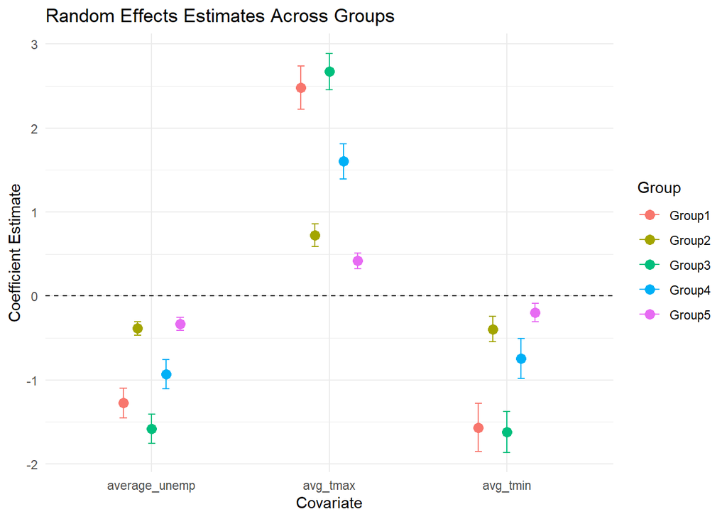

```r
library(ggplot2)

coef_df %>%
  filter(term %in% c("avg_tmax", "avg_tmin", "average_unemp")) %>%
  ggplot(aes(x = term, y = estimate, color = Group)) +
  geom_point(position = position_dodge(width = 0.4), size = 3) +
  geom_errorbar(
    aes(ymin = estimate - 1.96 * std.error,
        ymax = estimate + 1.96 * std.error),
    position = position_dodge(width = 0.4),
    width = 0.2
  ) +
  geom_hline(yintercept = 0, linetype = "dashed") +
  labs(
    title = "Random Effects Estimates Across Groups",
    x = "Covariate",
    y = "Coefficient Estimate"
  ) +
  theme_minimal()
```

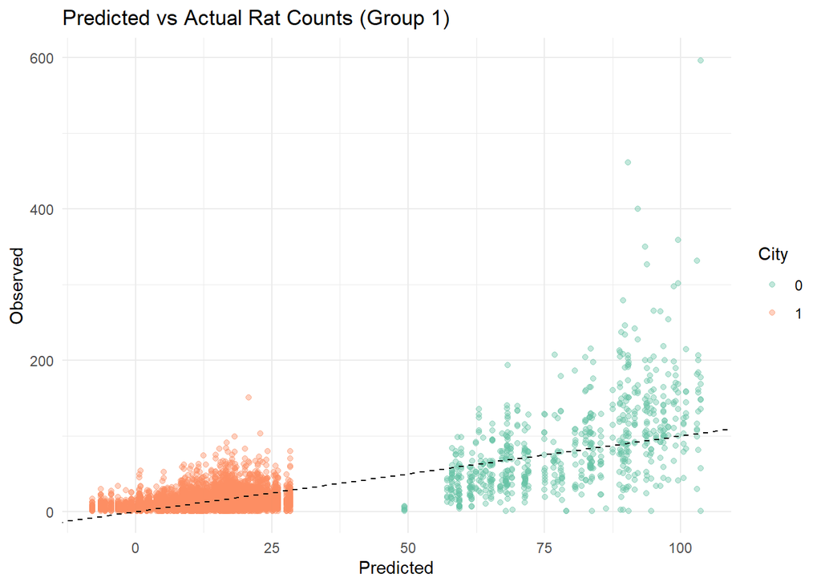

```r
panel_data1$City <- factor(panel_data1$City)
panel_data2$City <- factor(panel_data2$City)
panel_data3$City <- factor(panel_data3$City)
panel_data4$City <- factor(panel_data4$City)
panel_data5$City <- factor(panel_data5$City)





panel_data1$pred <- predict(re_model1)

ggplot(panel_data1, aes(x = pred, y = rat_count, color = City)) +
  geom_point(alpha = 0.4) +
  geom_abline(slope = 1, intercept = 0, linetype = "dashed", color = "black") +
  scale_color_brewer(palette = "Set2") +
  labs(
    title = "Predicted vs Actual Rat Counts (Group 1)",
    x = "Predicted",
    y = "Observed",
    color = "City"
  ) +
  theme_minimal()
```

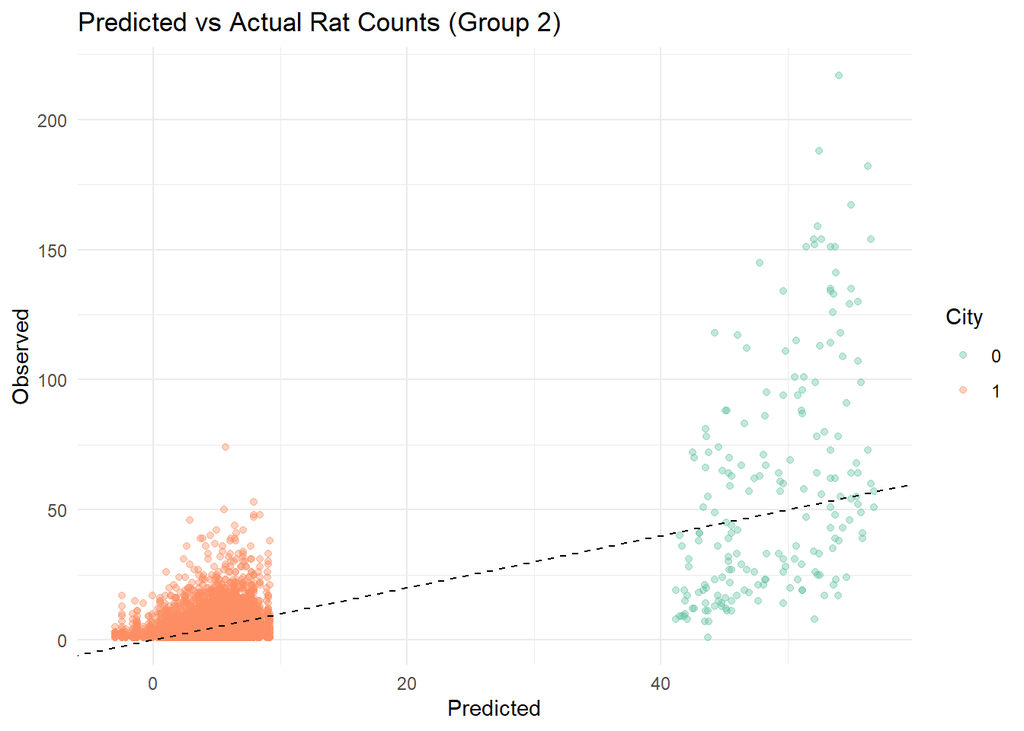

```r
panel_data2$pred <- predict(re_model2)

ggplot(panel_data2, aes(x = pred, y = rat_count, color = City)) +
  geom_point(alpha = 0.4) +
  geom_abline(slope = 1, intercept = 0, linetype = "dashed", color = "black") +
  scale_color_brewer(palette = "Set2") +
  labs(
    title = "Predicted vs Actual Rat Counts (Group 2)",
    x = "Predicted",
    y = "Observed",
    color = "City"
  ) +
  theme_minimal()
```

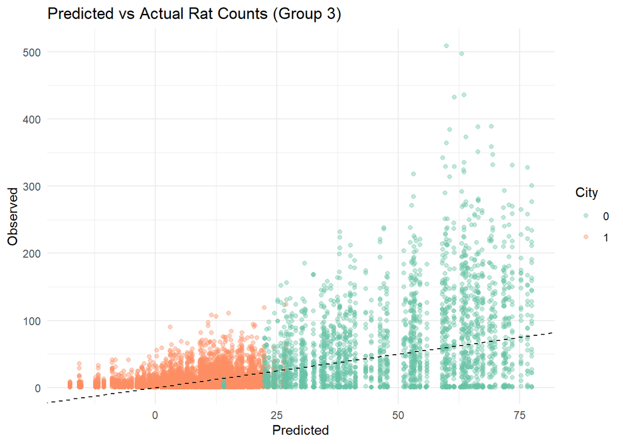

```r
panel_data3$pred <- predict(re_model3)

ggplot(panel_data3, aes(x = pred, y = rat_count, color = City)) +
  geom_point(alpha = 0.4) +
  geom_abline(slope = 1, intercept = 0, linetype = "dashed", color = "black") +
  scale_color_brewer(palette = "Set2") +
  labs(
    title = "Predicted vs Actual Rat Counts (Group 3)",
    x = "Predicted",
    y = "Observed",
    color = "City"
  ) +
  theme_minimal()
```

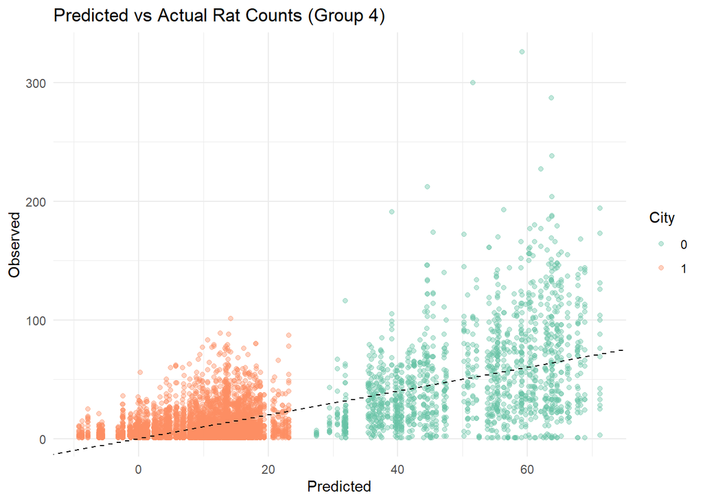

```r
panel_data4$pred <- predict(re_model4)

ggplot(panel_data4, aes(x = pred, y = rat_count, color = City)) +
  geom_point(alpha = 0.4) +
  geom_abline(slope = 1, intercept = 0, linetype = "dashed", color = "black") +
  scale_color_brewer(palette = "Set2") +
  labs(
    title = "Predicted vs Actual Rat Counts (Group 4)",
    x = "Predicted",
    y = "Observed",
    color = "City"
  ) +
  theme_minimal()
```

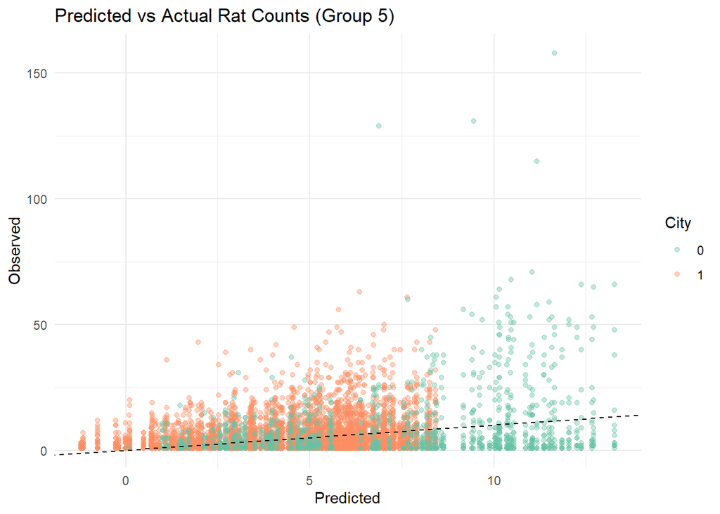

```r
panel_data5$pred <- predict(re_model5)

ggplot(panel_data5, aes(x = pred, y = rat_count, color = City)) +
  geom_point(alpha = 0.4) +
  geom_abline(slope = 1, intercept = 0, linetype = "dashed", color = "black") +
  scale_color_brewer(palette = "Set2") +
  labs(
    title = "Predicted vs Actual Rat Counts (Group 5)",
    x = "Predicted",
    y = "Observed",
    color = "City"
  ) +
  theme_minimal()
```

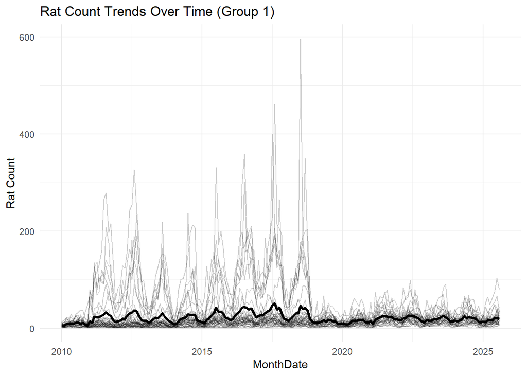

```r
ggplot(group1, aes(x = MonthDate, y = rat_count, group = ZCTA)) +
  geom_line(alpha = 0.2) +
  stat_summary(aes(group = 1), fun = mean, geom = "line",
               linewidth = 1.2, color = "black") +
  labs(
    title = "Rat Count Trends Over Time (Group 1)",
    y = "Rat Count"
  ) +
  theme_minimal()
```

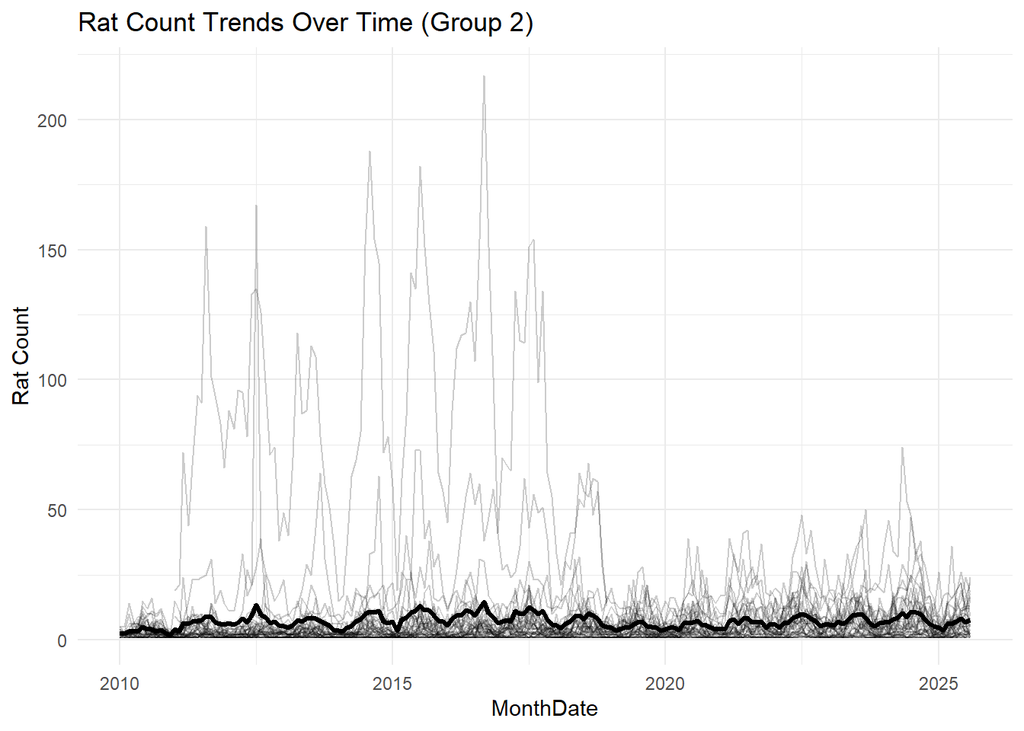

```r
ggplot(group2, aes(x = MonthDate, y = rat_count, group = ZCTA)) +
  geom_line(alpha = 0.2) +
  stat_summary(aes(group = 2), fun = mean, geom = "line",
               linewidth = 1.2, color = "black") +
  labs(
    title = "Rat Count Trends Over Time (Group 2)",
    y = "Rat Count"
  ) +
  theme_minimal()
```

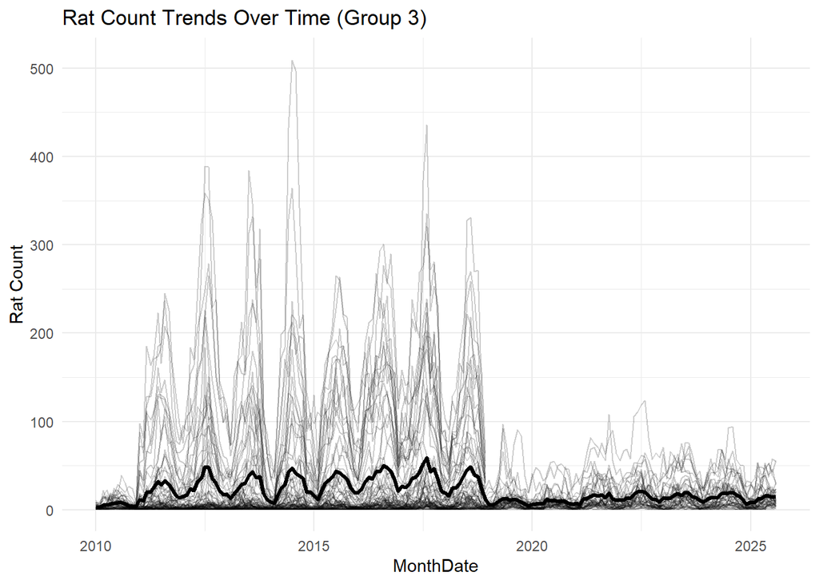

```r
ggplot(group3, aes(x = MonthDate, y = rat_count, group = ZCTA)) +
  geom_line(alpha = 0.2) +
  stat_summary(aes(group = 3), fun = mean, geom = "line",
               linewidth = 1.2, color = "black") +
  labs(
    title = "Rat Count Trends Over Time (Group 3)",
    y = "Rat Count"
  ) +
  theme_minimal()
```

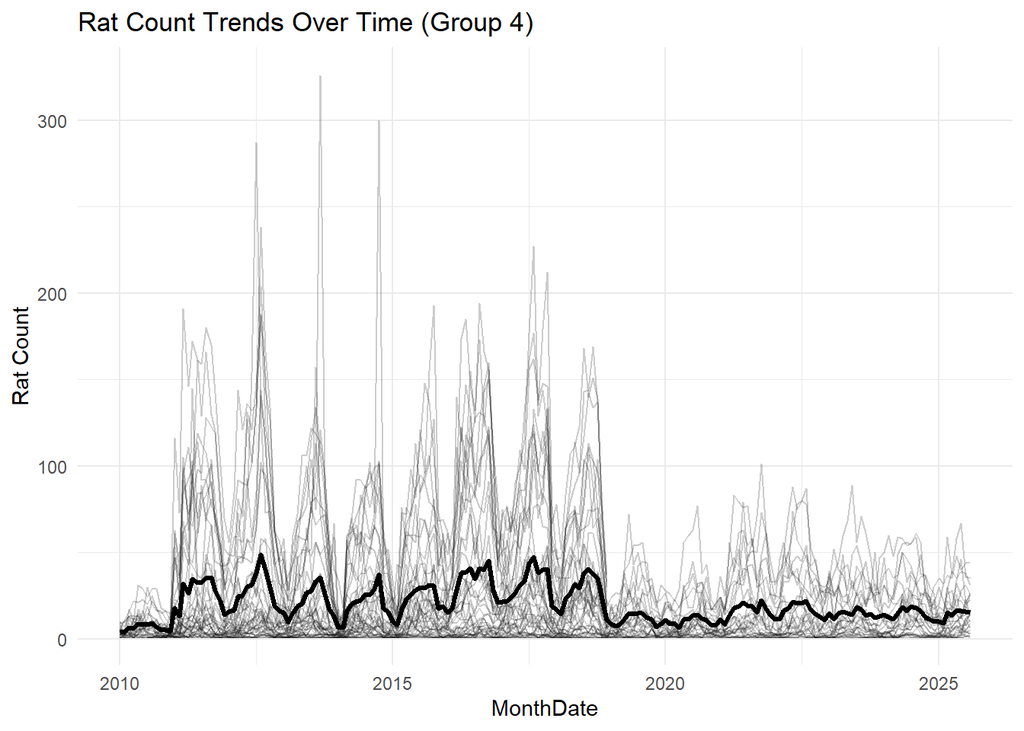

```r
ggplot(group4, aes(x = MonthDate, y = rat_count, group = ZCTA)) +
  geom_line(alpha = 0.2) +
  stat_summary(aes(group = 4), fun = mean, geom = "line",
               linewidth = 1.2, color = "black") +
  labs(
    title = "Rat Count Trends Over Time (Group 4)",
    y = "Rat Count"
  ) +
  theme_minimal()
```

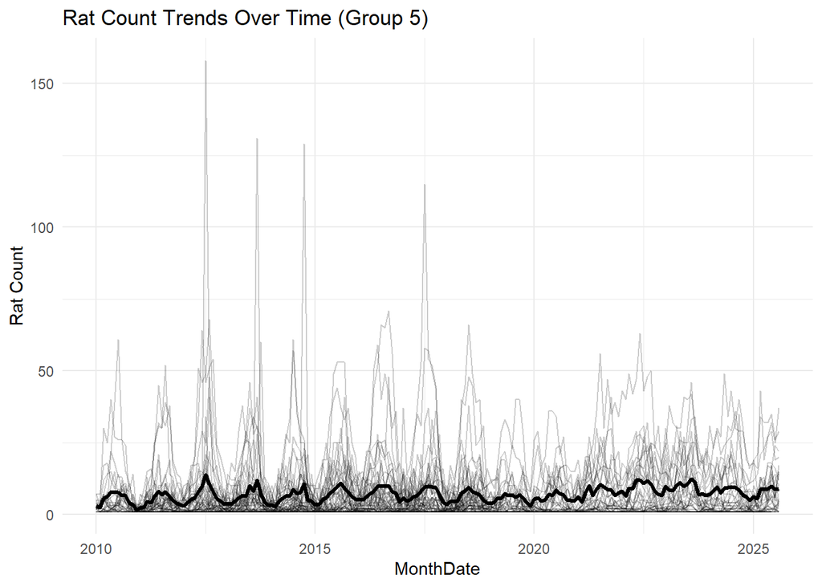

```r
ggplot(group5, aes(x = MonthDate, y = rat_count, group = ZCTA)) +
  geom_line(alpha = 0.2) +
  stat_summary(aes(group = 5), fun = mean, geom = "line",
               linewidth = 1.2, color = "black") +
  labs(
    title = "Rat Count Trends Over Time (Group 5)",
    y = "Rat Count"
  ) +
  theme_minimal()
```

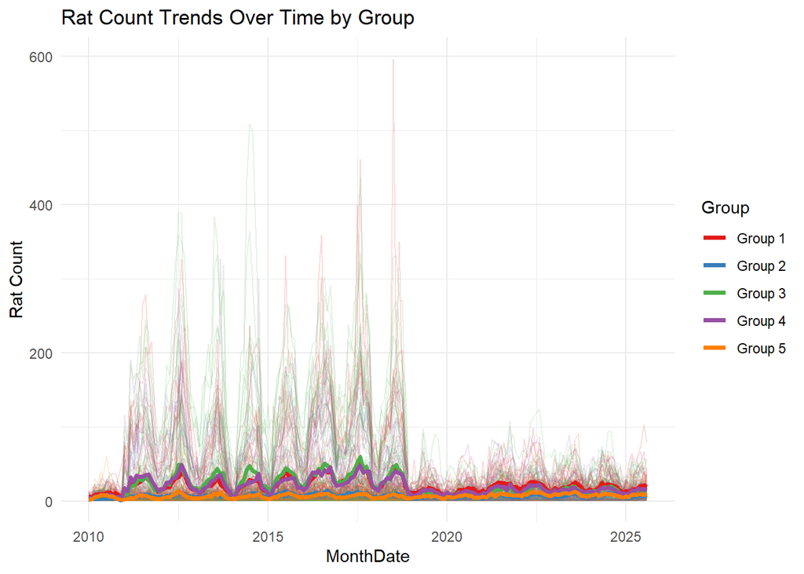

```r
group1$Group <- "Group 1"
group2$Group <- "Group 2"
group3$Group <- "Group 3"
group4$Group <- "Group 4"
group5$Group <- "Group 5"
library(dplyr)

all_groups <- bind_rows(group1, group2, group3, group4, group5)

ggplot(all_groups, aes(x = MonthDate, y = rat_count, group = interaction(Group, ZCTA))) +
  geom_line(alpha = 0.15, aes(color = Group)) +
  stat_summary(
    aes(group = Group, color = Group),
    fun = mean,
    geom = "line",
    linewidth = 1.4
  ) +
  scale_color_brewer(palette = "Set1") +
  labs(
    title = "Rat Count Trends Over Time by Group",
    y = "Rat Count",
    color = "Group"
  ) +
  theme_minimal()
```

# conclusion

**This analysis shows clear differences in reported rat sightings between Chicago and New York City, even after accounting for weather, unemployment, and seasonal effects. Chicago ZCTA codes consistently show higher monthly counts, suggesting that institutional and reporting mechanisms, rather than purely environmental factors, shape observed complaint patterns. Neighborhood level heterogeneity further highlights how local demographics interact with reporting systems. These findings indicate the importance of considering institutional context when interpreting urban pest data and suggest that city-level differences in reporting infrastructure can significantly influence the patterns captured in public complaint datasets.**